# Practical Machine Learning Project

Tzu-Chun Liang

2/6/2018

## Brief Summary

The goal of of this project is to predict the “classe” variable in the training set provided by Groupwire@LES. The dataset contains information collected over weight lifting exercises using personal monitoring devices. The report covers data cleaning, predication model construction, and expected out-of-sample rate.

## Setup

1. Load the required package and CPU parameter
2. Download the Data. (Provided by http://groupware.les.inf.puc-rio.br/har)

```r
trainingFileURL <- "https://d396qusza40orc.cloudfront.net/predmachlearn/pml-training.csv"
testFileURL <- "https://d396qusza40orc.cloudfront.net/predmachlearn/pml-testing.csv"
destfile1 = "./training.csv"
destfile2 = "./test.csv"

if(!file.exists(destfile1)) {
  download.file(trainingFileURL, destfile1, method = "curl")
  load("./training.csv")
}

if(!file.exists(destfile2)) {
  download.file(testFileURL, destfile2, method = "curl")
  load("./test.csv")
}
```

3. Load data and perform feature selection by removing irrelavent columns.

```r
trainData <- read.csv(destfile1, na.string = c("NA", ""))
testData <- read.csv(destfile2, na.string = c("NA", ""))
colnames(trainData)
```

```
##   [1] "X"                        "user_name"
##   [3] "raw_timestamp_part_1"     "raw_timestamp_part_2"
##   [5] "cvtd_timestamp"           "new_window"
##   [7] "num_window"               "roll_belt"
##   [9] "pitch_belt"               "yaw_belt"
##  [11] "total_accel_belt"         "kurtosis_roll_belt"
##  [13] "kurtosis_picth_belt"      "kurtosis_yaw_belt"
##  [15] "skewness_roll_belt"       "skewness_roll_belt.1"
##  [17] "skewness_yaw_belt"        "max_roll_belt"
##  [19] "max_picth_belt"           "max_yaw_belt"
##  [21] "min_roll_belt"            "min_pitch_belt"
##  [23] "min_yaw_belt"             "amplitude_roll_belt"
##  [25] "amplitude_pitch_belt"     "amplitude_yaw_belt"
##  [27] "var_total_accel_belt"     "avg_roll_belt"
##  [29] "stddev_roll_belt"         "var_roll_belt"
```

[output cut: 65 more lines]

```r
uselessFeature <- c("X", "cvtd_timestamp", "user_name",
                    "raw_timestamp_part_1",
                    "raw_timestamp_part_2",
                    "new_window",
                    "num_window")
newTrainData <- trainData[,-which(names(trainData) %in% uselessFeature)]
newTestData<- testData[,-which(names(testData) %in% uselessFeature)]
```

4. Clean the data by removing all NA columns.

```r
cleanedTrainData <- newTrainData[,colSums(is.na(newTrainData)) == 0]
cleanedTestData <- newTestData[,colSums(is.na(newTestData)) == 0]
dim(cleanedTrainData)
```

```
## [1] 19622    53
```

```r
dim(cleanedTestData)
```

```
## [1] 20 53
```

5. Load data and split 1/4 of the cleaned training data as validation set.

```r
set.seed(2-6-2018)
inTrain <- createDataPartition(cleanedTrainData$classe, p = 3/4)[[1]]
training = cleanedTrainData[inTrain,]
validation = cleanedTrainData[-inTrain,]
```

## Building Predication Models

1. Build a first model using classification tree predication which is good for non-linear relationship, then apply the predication on the validation data to obtain the accuracy. Note the training control is changed from boostrapping to cross validation. The number of subsamples is reduced from 10 to 5 to save some computational time.

```r
fitControl <- trainControl(method = "cv", number = 5)
model1 <- train(classe ~ ., data = training, method = "rpart", trControl = fitControl)
print(model1)
```

```
## CART
##
## 14718 samples
##    52 predictor
##     5 classes: 'A', 'B', 'C', 'D', 'E'
##
## No pre-processing
## Resampling: Cross-Validated (5 fold)
## Summary of sample sizes: 11774, 11776, 11775, 11773, 11774
## Resampling results across tuning parameters:
##
##   cp          Accuracy   Kappa
##   0.02731099  0.5731061  0.45854458
##   0.04371024  0.4194386  0.21702420
##   0.11715561  0.3003783  0.02462756
##
## Accuracy was used to select the optimal model using the largest value.
## The final value used for the model was cp = 0.02731099.
```

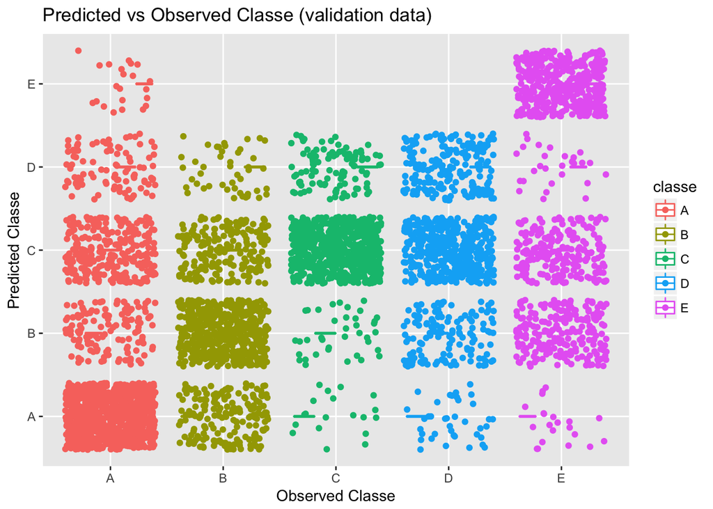

```r
pred1 <- predict(model1, validation)
cMatrix1 <- confusionMatrix(pred1, validation$classe)
qplot(classe, pred1, data = validation,  colour = classe, geom = c("boxplot", "jitter"), main = "Predicted vs Observed Classe (validation data)", xlab = "Observed Classe", ylab = "Predicted Classe")
```

```r
cMatrix1$overall[1]
```

```
##  Accuracy
## 0.5513866
```

The accuracy of this model is 0.5513866, so the out-of-sample error rate is about 0.45.

2. Build a second model similar to the first model but change the method to Random Forest.

```r
model2 <- randomForest(classe ~ ., data = training, trControl = fitControl)
print(model2)
```

```
##
## Call:
##  randomForest(formula = classe ~ ., data = training, trControl = fitControl)
##                Type of random forest: classification
##                      Number of trees: 500
## No. of variables tried at each split: 7
##
##         OOB estimate of  error rate: 0.5%
## Confusion matrix:
##      A    B    C    D    E  class.error
## A 4182    2    0    0    1 0.0007168459
## B   15 2825    8    0    0 0.0080758427
## C    0   14 2550    3    0 0.0066225166
## D    0    0   24 2386    2 0.0107794362
## E    0    0    0    5 2701 0.0018477458
```

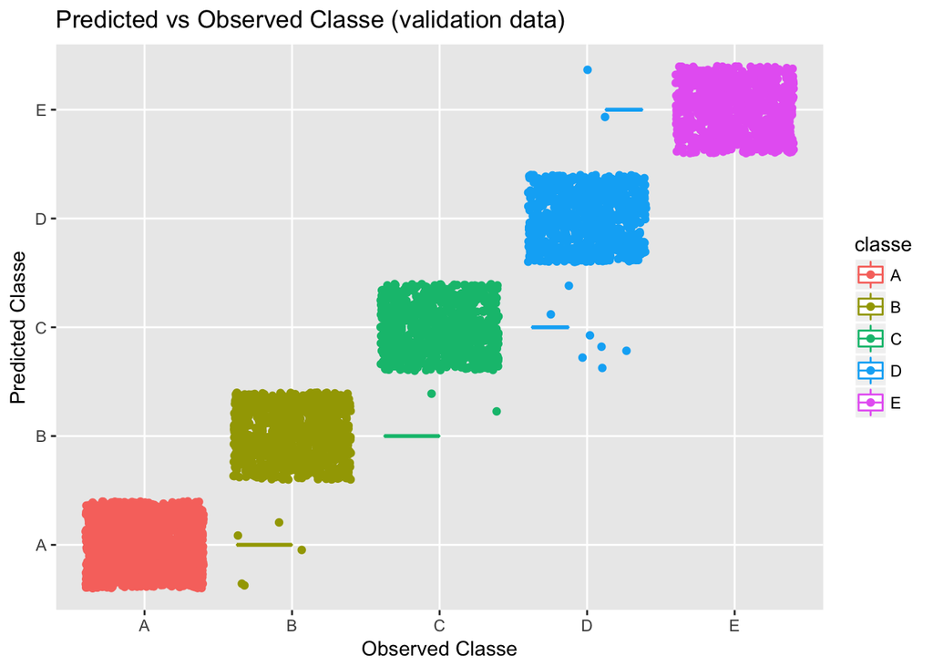

```r
pred2 <- predict(model2, validation)
cMatrix2 <- confusionMatrix(pred2, validation$classe)
qplot(classe, pred2, data = validation,  colour = classe, geom = c("boxplot", "jitter"), main = "Predicted vs Observed Classe (validation data)", xlab = "Observed Classe", ylab = "Predicted Classe")
```

```r
cMatrix2$overall[1]
```

```
##  Accuracy
## 0.9967374
```

## Conclusion

The second model (trained by Random Forest) is used to predict the classe variable of the test data.

```r
finalPred <- predict(model2, cleanedTestData)
finalPred
```

```
##  1  2  3  4  5  6  7  8  9 10 11 12 13 14 15 16 17 18 19 20
##  B  A  B  A  A  E  D  B  A  A  B  C  B  A  E  E  A  B  B  B
## Levels: A B C D E
```